# Prediction of quality of exercise

Bhanuday Birla

Sunday, August 7, 2016

**Overview**

People do exercise to achieve good health and physique.They also used to qunatify the amount of exercise they are doing but they dont know if they are doing it the right way. This report has an objective to classify the fairness of weight lifting exercise. For the classification, we will use some machine learning techniques for training on data and then the trained model can be used to predict class of fairness of exercise. The collected data is of various parameters measured by different sensors fitted to a person’s various body parts. These measurements are taken with or without making various mistakes in exercise. On the basis of various mistakes and perfectly done exercise, every observation was labled with a class. We have some observations with known class label, which we will use for training and some without the class will be used for prediction.

**Data Preparation**

On looking the dimension of data we found that there are 19622 observations of 160 variables in training set. We need to partition this data into two partitions namely training and testing set in order to validate the predictive models using test set. we have partitioned data into 80% training data and 20% testing data.

**Feature Selection**

There are 160 features in the data so there is need to compress the data vertically that means dimenstionality reduction. Firstly we have removed the columns which have null or no values. After removing columns with null values we are left with 54 variables including outcome variable. Again there is need to reduce dimensions further. In order to reduce further, we have plotted variable importance plot and have taken top ten important varibales.

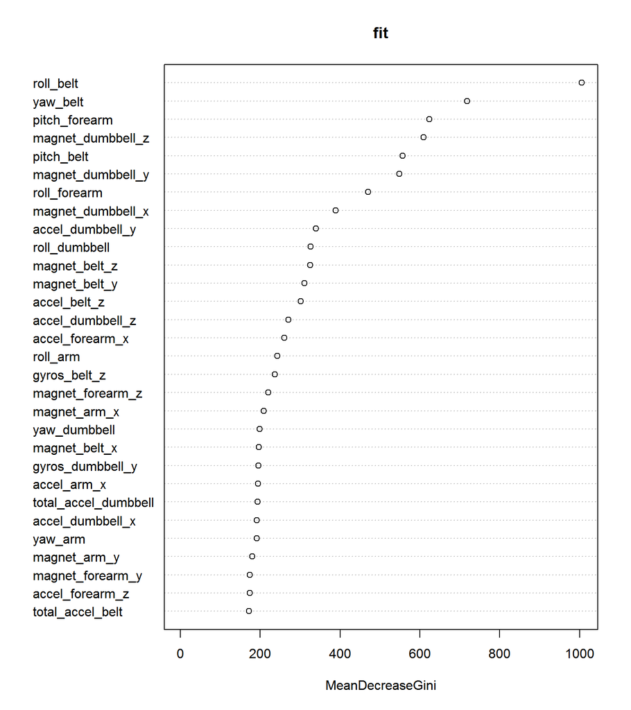

```
##                   roll_belt yaw_belt pitch_forearm magnet_dumbbell_z
## roll_belt            1.0000  0.81545       0.16958          -0.49769
## yaw_belt             0.8154  1.00000      -0.03242          -0.21401
## pitch_forearm        0.1696 -0.03242       1.00000          -0.16466
## magnet_dumbbell_z   -0.4977 -0.21401      -0.16466           1.00000
## pitch_belt          -0.2163 -0.69947       0.25010          -0.25716
## magnet_dumbbell_y   -0.2868 -0.03308      -0.15330           0.25926
## roll_forearm        -0.1461 -0.17677      -0.04920          -0.06364
## magnet_dumbbell_x    0.3166 -0.02426       0.27191          -0.17204
## accel_dumbbell_y    -0.2671  0.05170      -0.23183           0.22551
## roll_dumbbell       -0.1313  0.09430      -0.10798           0.13259
##                   pitch_belt magnet_dumbbell_y roll_forearm
## roll_belt            -0.2163          -0.28680     -0.14607
## yaw_belt             -0.6995          -0.03308     -0.17677
## pitch_forearm         0.2501          -0.15330     -0.04920
## magnet_dumbbell_z    -0.2572           0.25926     -0.06364
## pitch_belt            1.0000          -0.36258      0.14342
## magnet_dumbbell_y    -0.3626           1.00000     -0.16658
## roll_forearm          0.1434          -0.16658      1.00000
## magnet_dumbbell_x     0.4593          -0.76910      0.16064
## accel_dumbbell_y     -0.4509           0.49187      0.13783
## roll_dumbbell        -0.3505           0.40781     -0.01960
##                   magnet_dumbbell_x accel_dumbbell_y roll_dumbbell
## roll_belt                   0.31660          -0.2671       -0.1313
## yaw_belt                   -0.02426           0.0517        0.0943
## pitch_forearm               0.27191          -0.2318       -0.1080
## magnet_dumbbell_z          -0.17204           0.2255        0.1326
## pitch_belt                  0.45931          -0.4509       -0.3505
## magnet_dumbbell_y          -0.76910           0.4919        0.4078
## roll_forearm                0.16064           0.1378       -0.0196
## magnet_dumbbell_x           1.00000          -0.2703       -0.1566
## accel_dumbbell_y           -0.27026           1.0000        0.7214
## roll_dumbbell              -0.15659           0.7214        1.0000
```

There is siginificant correlation(0.82) between roll_belt and yaw_belt variables so we need to get rid of one of them. Having seen that variable roll_belt is more important than yaw_belt so we can drop yaw_belt from our predictor variables.

Now we are going to use different widely used classification technique. First we will try random forest technique which is least prabable to introduce overfitting into model.

**Random Forest**

We have trained a model, random forest using caret package and predicted classe variable on test set. The confusion matrix for our prediction is given below:

```
## Confusion Matrix and Statistics
##
##           Reference
## Prediction    A    B    C    D    E
##          A 1104    6    1    0    0
##          B    4  735    2    3    3
##          C    7   11  675    5    2
##          D    0    4    6  635    3
##          E    1    3    0    0  713
##
## Overall Statistics
##
##                Accuracy : 0.984
##                  95% CI : (0.98, 0.988)
##     No Information Rate : 0.284
##     P-Value [Acc > NIR] : <2e-16
##
##                   Kappa : 0.98
##  Mcnemar's Test P-Value : NA
##
## Statistics by Class:
##
##                      Class: A Class: B Class: C Class: D Class: E
## Sensitivity             0.989    0.968    0.987    0.988    0.989
## Specificity             0.998    0.996    0.992    0.996    0.999
## Pos Pred Value          0.994    0.984    0.964    0.980    0.994
## Neg Pred Value          0.996    0.992    0.997    0.998    0.998
## Prevalence              0.284    0.193    0.174    0.164    0.184
## Detection Rate          0.281    0.187    0.172    0.162    0.182
## Detection Prevalence    0.283    0.190    0.178    0.165    0.183
## Balanced Accuracy       0.993    0.982    0.990    0.992    0.994
```

**Prediction**

With the help of the model, we have predicted the classe variable for 20 provided test cases:

```
##  1  2  3  4  5  6  7  8  9 10 11 12 13 14 15 16 17 18 19 20
##  B  A  B  A  A  E  D  B  A  A  B  C  B  A  E  E  A  B  B  B
## Levels: A B C D E
```